# Preventable Mortality Under 75: District-Level Variation in England

### Factor analysis

Two principal component analyses use the time dimension in the data. The first treats the seven annual time points as variables, with each district as an observation, to identify whether districts cluster by mortality trajectory: consistently high, consistently low, or changing direction over 2011–2019. The second uses the seven IMD domain scores aggregated from LSOA to district level, identifying which combinations of deprivation dimensions are most strongly associated with mortality variation beyond the composite score.

#### Part A: Temporal mortality trajectories

```r
traj_wide <- panel |>
  filter(Sex == "Persons") |>
  select(AreaCode, AreaName, year, Value) |>
  pivot_wider(names_from = year, values_from = Value, names_prefix = "y") |>
  left_join(persons_avg |> select(AreaCode, avg_imd, avg_ethnicity),
            by = "AreaCode") |>
  filter(complete.cases(across(starts_with("y"))))

traj_matrix <- traj_wide |> select(starts_with("y")) |> scale()
pca_traj    <- prcomp(traj_matrix, center = FALSE, scale. = FALSE)

scree_traj <- tibble(
  PC      = seq_along(pca_traj$sdev),
  var_exp = (pca_traj$sdev^2) / sum(pca_traj$sdev^2) * 100,
  cum_var = cumsum((pca_traj$sdev^2) / sum(pca_traj$sdev^2) * 100)
)
```

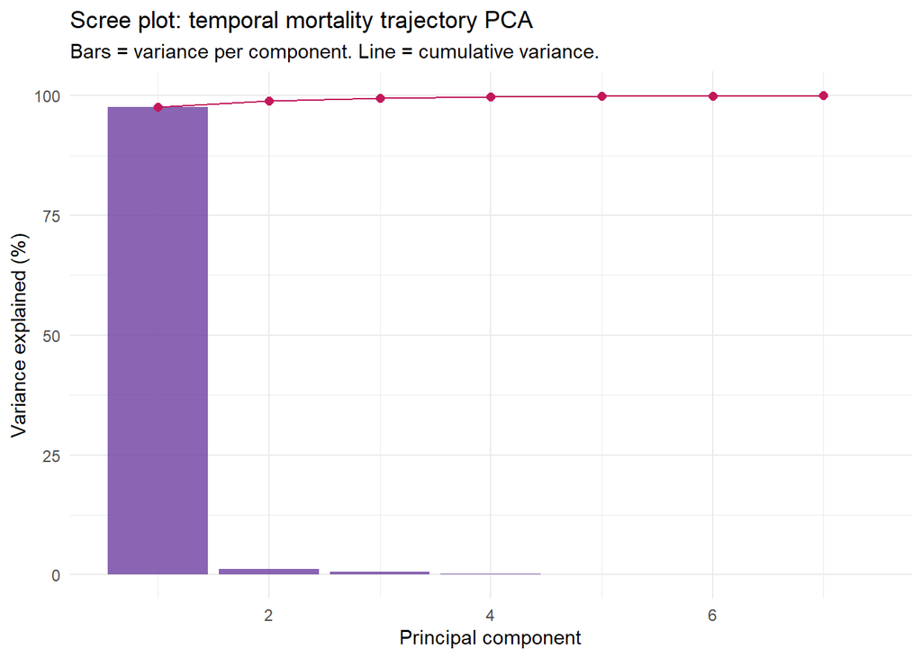

Figure 5: Scree plot for temporal mortality trajectory PCA

```r
ggplot(scree_traj, aes(x = PC, y = var_exp)) +
  geom_col(fill = "#6B3FA0", alpha = 0.8) +
  geom_line(aes(y = cum_var), colour = "#C2185B") +
  geom_point(aes(y = cum_var), colour = "#C2185B", size = 2) +
  labs(
    title    = "Scree plot: temporal mortality trajectory PCA",
    subtitle = "Bars = variance per component. Line = cumulative variance.",
    x        = "Principal component",
    y        = "Variance explained (%)"
  ) +
  theme_minimal()
```

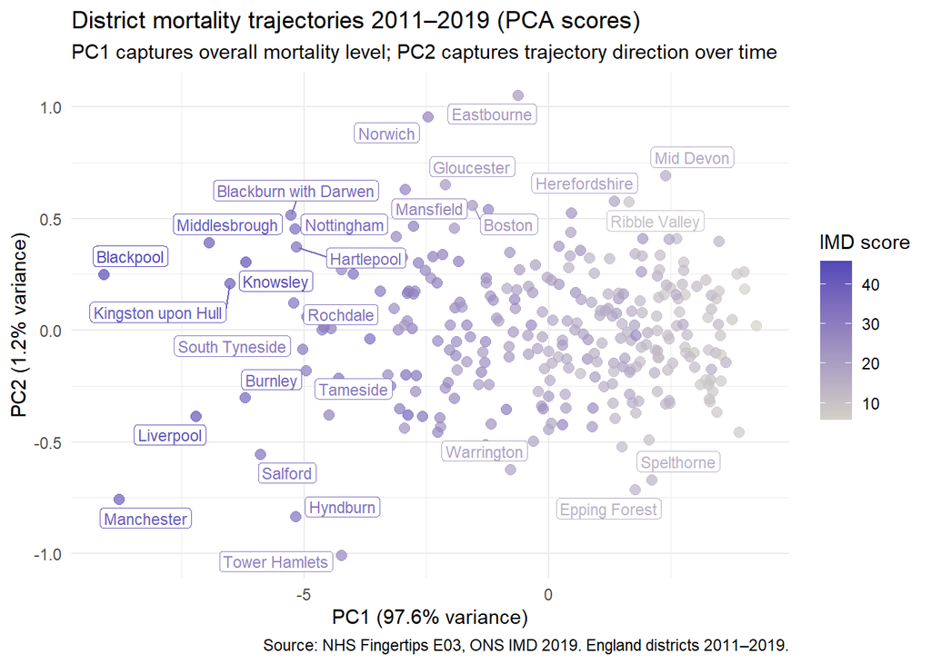

Figure 6: District trajectory scores, PC1 vs PC2 coloured by IMD

```r
scores_traj <- as.data.frame(pca_traj$x) |>
  bind_cols(traj_wide |> select(AreaCode, AreaName, avg_imd, avg_ethnicity))

outlier_threshold_pc1 <- quantile(abs(scores_traj$PC1), 0.95)
outlier_threshold_pc2 <- quantile(abs(scores_traj$PC2), 0.95)

ggplot(scores_traj, aes(x = PC1, y = PC2, colour = avg_imd)) +
  geom_point(alpha = 0.7, size = 2.5) +
  geom_label_repel(
    data = scores_traj |>
      filter(abs(PC1) > outlier_threshold_pc1 | abs(PC2) > outlier_threshold_pc2),
    aes(label = AreaName),
    size = 3, fill = "white", label.padding = 0.15, max.overlaps = 12
  ) +
  scale_colour_gradient(low = "#D3D1C7", high = "#534AB7", name = "IMD score") +
  labs(
    title    = "District mortality trajectories 2011–2019 (PCA scores)",
    subtitle = "PC1 captures overall mortality level; PC2 captures trajectory direction over time",
    x        = paste0("PC1 (", round(scree_traj$var_exp[1], 1), "% variance)"),
    y        = paste0("PC2 (", round(scree_traj$var_exp[2], 1), "% variance)"),
    caption  = "Source: NHS Fingertips E03, ONS IMD 2019. England districts 2011–2019."
  ) +
  theme_minimal()
```

#### Part B: IMD domain structure

```r
library(readxl)
library(tibble)

imd_domains_raw <- read_excel(
  "../data/raw/direct IMD scores.xlsx",
  sheet = "IoD2019 Scores"
) |>
  rename(
    AreaCode    = `Local Authority District code (2019)`,
    income      = `Income Score (rate)`,
    employment  = `Employment Score (rate)`,
    education   = `Education, Skills and Training Score`,
    health      = `Health Deprivation and Disability Score`,
    crime       = `Crime Score`,
    housing     = `Barriers to Housing and Services Score`,
    environment = `Living Environment Score`
  ) |>
  filter(!AreaCode %in% c("E09000001", "E06000053", "E06000060")) |>
  group_by(AreaCode) |>
  summarise(across(c(income, employment, education, health, crime, housing, environment),
                   \(x) mean(x, na.rm = TRUE)),
            .groups = "drop") |>
  inner_join(
    persons_avg |> select(AreaCode, AreaName, avg_mortality, avg_imd, avg_ethnicity),
    by = "AreaCode"
  )

imd_matrix <- imd_domains_raw |> select(income:environment) |> scale()
pca_imd    <- prcomp(imd_matrix, center = FALSE, scale. = FALSE)

scree_imd <- tibble(
  PC      = seq_along(pca_imd$sdev),
  var_exp = (pca_imd$sdev^2) / sum(pca_imd$sdev^2) * 100,
  cum_var = cumsum((pca_imd$sdev^2) / sum(pca_imd$sdev^2) * 100)
)
```

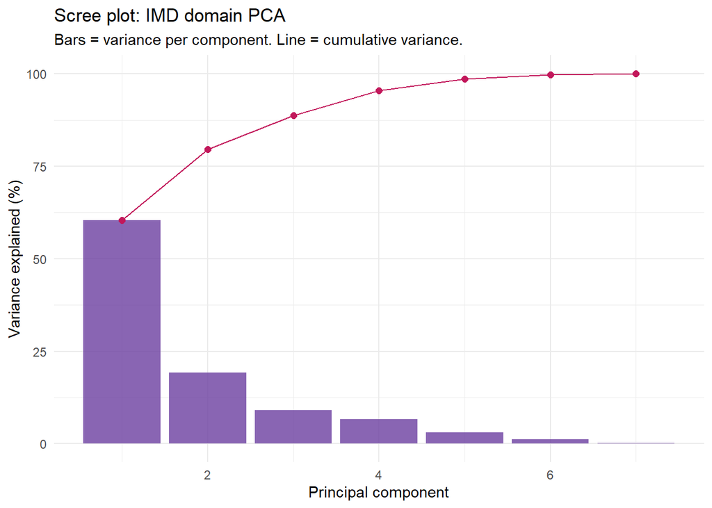

Figure 7: Scree plot for IMD domain PCA

```r
ggplot(scree_imd, aes(x = PC, y = var_exp)) +
  geom_col(fill = "#6B3FA0", alpha = 0.8) +
  geom_line(aes(y = cum_var), colour = "#C2185B") +
  geom_point(aes(y = cum_var), colour = "#C2185B", size = 2) +
  labs(
    title    = "Scree plot: IMD domain PCA",
    subtitle = "Bars = variance per component. Line = cumulative variance.",
    x        = "Principal component",
    y        = "Variance explained (%)"
  ) +
  theme_minimal()
```

```r
loadings_imd <- as.data.frame(pca_imd$rotation[, 1:3]) |>
  rownames_to_column("Domain") |>
  mutate(
    Domain = recode(Domain,
      "income"      = "Income deprivation",
      "employment"  = "Employment deprivation",
      "education"   = "Education, skills & training",
      "health"      = "Health deprivation & disability",
      "crime"       = "Crime",
      "housing"     = "Barriers to housing & services",
      "environment" = "Living environment"
    ),
    across(starts_with("PC"), ~ round(., 3))
  )

kable(loadings_imd,
      col.names = c("IMD domain", "PC1", "PC2", "PC3"),
      caption   = "Table 7: IMD domain PCA loadings (first three components)")
```

Table 7: IMD domain PCA loadings (first three components)

| IMD domain | PC1 | PC2 | PC3 |
| --- | --- | --- | --- |
| Income deprivation | -0.466 | 0.139 | 0.084 |
| Employment deprivation | -0.470 | -0.059 | -0.012 |
| Education, skills & training | -0.412 | -0.209 | 0.192 |
| Health deprivation & disability | -0.462 | -0.105 | -0.057 |
| Crime | -0.356 | 0.252 | 0.342 |
| Barriers to housing & services | 0.149 | 0.680 | 0.569 |
| Living environment | -0.172 | 0.630 | -0.716 |

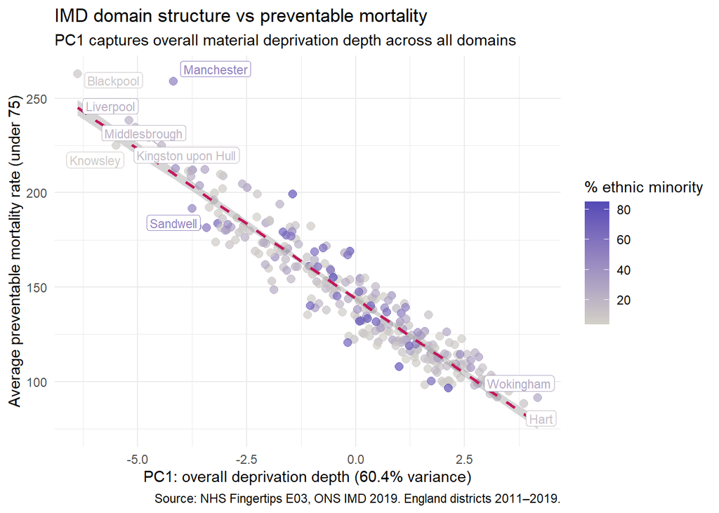

Figure 8: IMD domain PC1 vs preventable mortality, coloured by ethnic minority share

```r
scores_imd <- as.data.frame(pca_imd$x) |>
  bind_cols(imd_domains_raw |> select(AreaCode, AreaName, avg_mortality, avg_imd, avg_ethnicity))

ggplot(scores_imd, aes(x = PC1, y = avg_mortality, colour = avg_ethnicity)) +
  geom_point(alpha = 0.7, size = 2.5) +
  geom_smooth(method = "lm", se = TRUE, colour = "#C2185B", linetype = "dashed") +
  geom_label_repel(
    data = scores_imd |>
      filter(abs(PC1) > quantile(abs(PC1), 0.95) |
               avg_mortality > quantile(avg_mortality, 0.95)),
    aes(label = AreaName),
    size = 3, fill = "white", label.padding = 0.15, max.overlaps = 10
  ) +
  scale_colour_gradient(low = "#D3D1C7", high = "#534AB7", name = "% ethnic minority") +
  labs(
    title    = "IMD domain structure vs preventable mortality",
    subtitle = "PC1 captures overall material deprivation depth across all domains",
    x        = paste0("PC1: overall deprivation depth (",
                      round(scree_imd$var_exp[1], 1), "% variance)"),
    y        = "Average preventable mortality rate (under 75)",
    caption  = "Source: NHS Fingertips E03, ONS IMD 2019. England districts 2011–2019."
  ) +
  theme_minimal()
```

### Formal outlier testing

Districts that deviate substantially from their deprivation-predicted mortality rate were identified informally in the earlier analysis using a fixed residual threshold. Studentised residuals and Cook’s distance from a district-level OLS model (regressing average mortality on IMD score and ethnic minority composition) replace that approach with formal statistical criteria. Studentised residuals greater than 2 in absolute value flag districts whose mortality is poorly predicted by the model. Cook’s distance greater than 4/n identifies districts whose removal would materially shift the regression estimates.

**Interpreting the residuals requires secondary research.** A statistically identified outlier tells you that the model cannot explain a district’s mortality rate. It does not tell you why. For each formally identified outlier, the table below maps the district to its parent ICB (or predecessor CCG during the study period 2011–2019) and notes documented NHS activity that may partially account for the deviation. These are alternative explanations that the regression cannot rule out; they do not confirm that NHS investment is the sole or primary mechanism.

```r
m_district <- lm(avg_mortality ~ avg_imd + avg_ethnicity, data = persons_avg)

n_districts <- nrow(persons_avg)

outlier_df <- persons_avg |>
  mutate(
    fitted     = fitted(m_district),
    residual   = residuals(m_district),
    stud_resid = rstudent(m_district),
    cooks_d    = cooks.distance(m_district),
    outlier    = abs(stud_resid) > 2,
    influential = cooks_d > 4 / n_districts
  )
```

```r
outlier_table <- outlier_df |>
  filter(outlier | influential) |>
  arrange(desc(abs(stud_resid))) |>
  select(AreaName, avg_mortality, avg_imd, avg_ethnicity,
         stud_resid, cooks_d, outlier, influential) |>
  mutate(
    avg_mortality = round(avg_mortality, 1),
    avg_imd       = round(avg_imd, 1),
    avg_ethnicity = round(avg_ethnicity, 1),
    stud_resid    = round(stud_resid, 3),
    cooks_d       = round(cooks_d, 4),
    Flag          = case_when(
      outlier & influential ~ "Outlier + Influential",
      outlier               ~ "Outlier",
      influential           ~ "Influential",
      TRUE                  ~ ""
    )
  ) |>
  select(AreaName, avg_mortality, avg_imd, avg_ethnicity, stud_resid, cooks_d, Flag)

kable(outlier_table,
      col.names = c("District", "Avg mortality", "IMD score", "% ethnic minority",
                    "Studentised residual", "Cook's D", "Flag"),
      caption   = "Table 8: Formally identified outlier and high-influence districts")
```

Table 8: Formally identified outlier and high-influence districts

| District | Avg mortality | IMD score | % ethnic minority | Studentised residual | Cook’s D | Flag |
| --- | --- | --- | --- | --- | --- | --- |
| Enfield | 120.5 | 25.4 | 68.7 | -3.307 | 0.0883 | Outlier + Influential |
| Manchester | 258.9 | 40.0 | 51.3 | 3.193 | 0.0983 | Outlier + Influential |
| North Norfolk | 119.1 | 21.1 | 4.4 | -2.636 | 0.0159 | Outlier + Influential |
| Tower Hamlets | 199.2 | 28.0 | 77.1 | 2.505 | 0.0702 | Outlier + Influential |
| Birmingham | 181.5 | 37.6 | 57.1 | -2.410 | 0.0535 | Outlier + Influential |
| Haringey | 140.2 | 27.6 | 68.1 | -2.376 | 0.0466 | Outlier + Influential |
| Kensington and Chelsea | 118.8 | 22.0 | 67.3 | -2.303 | 0.0414 | Outlier + Influential |
| North Tyneside | 182.4 | 22.1 | 7.5 | 2.278 | 0.0108 | Outlier |
| West Devon | 111.7 | 18.0 | 5.1 | -2.202 | 0.0102 | Outlier |
| Babergh | 98.3 | 14.4 | 6.4 | -2.115 | 0.0102 | Outlier |
| Brent | 132.0 | 25.2 | 84.8 | -2.092 | 0.0620 | Outlier + Influential |
| Torridge | 133.6 | 23.0 | 3.9 | -2.072 | 0.0114 | Outlier |
| West Lindsey | 125.2 | 20.9 | 5.5 | -2.044 | 0.0091 | Outlier |
| Barnet | 100.2 | 16.0 | 63.8 | -1.851 | 0.0270 | Influential |
| Salford | 220.9 | 34.0 | 26.0 | 1.716 | 0.0141 | Influential |
| Newham | 155.2 | 29.8 | 85.2 | -1.680 | 0.0419 | Influential |
| Harrow | 96.5 | 14.9 | 79.5 | -1.645 | 0.0380 | Influential |
| Slough | 169.1 | 23.0 | 76.0 | 1.631 | 0.0286 | Influential |
| Hammersmith and Fulham | 167.0 | 22.3 | 61.7 | 1.523 | 0.0145 | Influential |
| Redbridge | 107.9 | 16.9 | 76.8 | -1.403 | 0.0241 | Influential |
| Knowsley | 225.1 | 43.6 | 7.6 | -1.314 | 0.0241 | Influential |
| Ealing | 133.2 | 22.6 | 75.7 | -1.188 | 0.0151 | Influential |
| Blackpool | 263.1 | 45.9 | 9.6 | 1.087 | 0.0191 | Influential |